# renz methods

Andrew Tolonen

2024

# Introduction

The goal of this notebook is to illustrate the methods provided with the renz package to calculate enzyme parameters: vmax and km.

# Setup

```r
rm(list = ls());

library(knitr);
library(tidyverse);
library(renz);
library(readxl);
```

```r
# HTML
knitr::opts_chunk$set(warning = F, message = F);
```

# File IO

```r
# Toy data for fe.progress
datafile = "/home/tolonen/Github/actolonen/Public/Analysis_Lab/Enzymes/Data/data_feprogress.tsv";
data.fe.toy = read.csv(datafile, header = TRUE, skip = 0, sep="\t");

# lab data for fe.progress
datafile = "/home/tolonen/Github/actolonen/Public/Analysis_Lab/Enzymes/Data/reactionRate.xlsx";
mydata = read_excel(datafile, sheet = "Rate", col_names = TRUE, skip = 0);
data.fe = as.data.frame(mydata);

# lab data for dir.mm
datafile = "/home/tolonen/Github/actolonen/Public/Analysis_Lab/Enzymes/Data/data_sv.csv";
mydata.mm = read.csv(datafile, header = TRUE, skip = 0, sep="\t");

# lab data for Lineweaver-Burk
datafile = "/home/tolonen/Github/actolonen/Public/Analysis_Lab/Enzymes/Data/data_sv.csv";
mydata.lb = read.csv(datafile, header = TRUE, skip = 0, sep="\t");
```

# renz functions: 3 ways to calc Km/Vmax

## 1. fE.progress(): Schnell-Mendoza equation

fE.progress() uses the Schnell-Mendoza equation to calculate Km, Vmax directly from a single curve of substrate consumption (substrate conc versus time). We get a nice linear curve and calculations of Km and Vmax when we use the toy data provided with the renz vignette:

### fE.progress(): toy data

```r
head(data.fe.toy, 10)
```

```
##     t         S
## 1   0 1.0000000
## 2   3 0.9038617
## 3   6 0.8150139
## 4   9 0.7265242
## 5  12 0.6520818
## 6  15 0.5813286
## 7  18 0.5204660
## 8  21 0.4545402
## 9  24 0.4032604
## 10 27 0.3581450
```

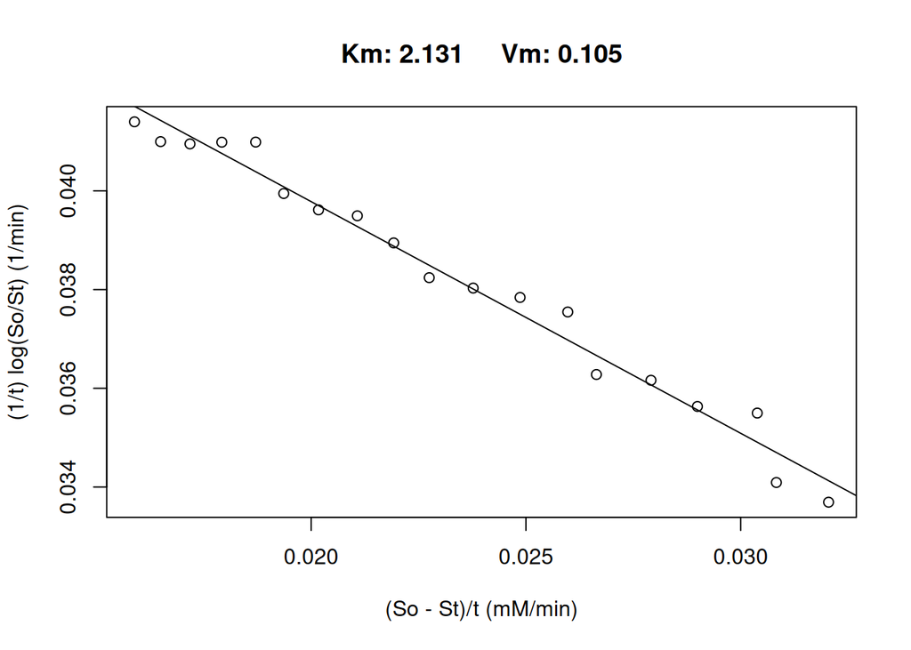

```
## 8.612173e-05 (2.13e-01): par = (2.131 0.105)
## 8.239429e-05 (4.17e-03): par = (2.181271 0.1068344)
## 8.239286e-05 (4.90e-06): par = (2.182213 0.1068685)
```

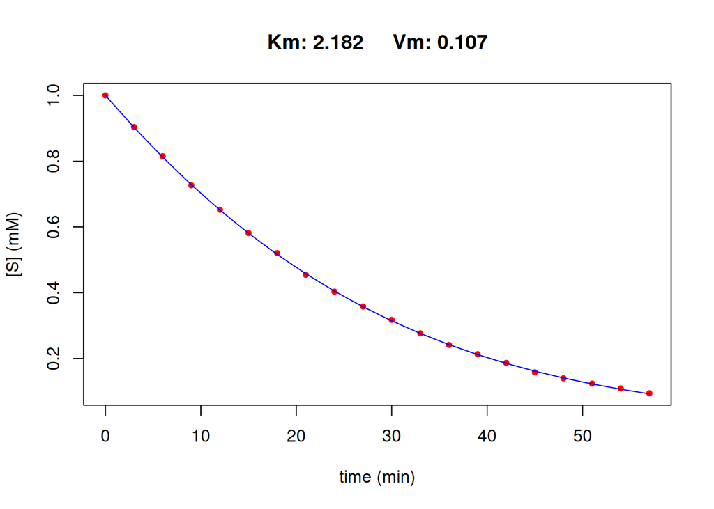

```r
# fE.progress, which makes use of the Schnell-Mendoza equation, allows us to obtain the kinetic parameters of the enzyme from a single curve.

output = fE.progress(data.fe.toy)
```

### fE.progress(): lab data

However, we get a non-linear function and negative values for Km and Vmax when we use fE.progress() on actual data from lab:

```r
output = fE.progress(data.fe)
```

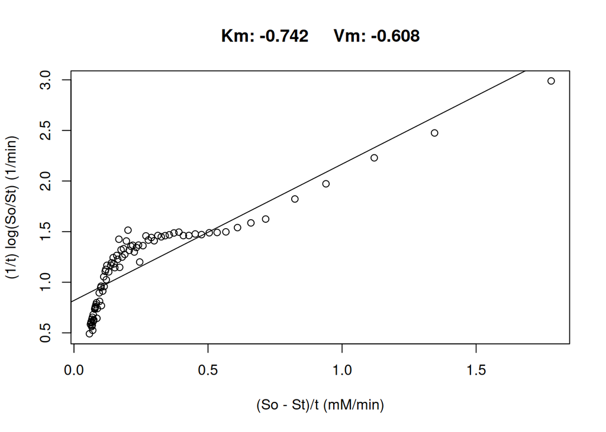

```
## 0.01185121  (1.39e+00): par = (-0.742 -0.608)
## 0.004461124 (4.09e-01): par = (-0.8875759 -0.8455525)
## 0.003807527 (7.04e-02): par = (-0.9634881 -0.9666399)
## 0.003787590 (6.44e-03): par = (-0.9794919 -0.9910865)
## 0.003787422 (4.64e-04): par = (-0.9808925 -0.9931228)
## 0.003787421 (3.27e-05): par = (-0.9809979 -0.9932789)
## 0.003787421 (2.27e-06): par = (-0.9810052 -0.9932895)
```

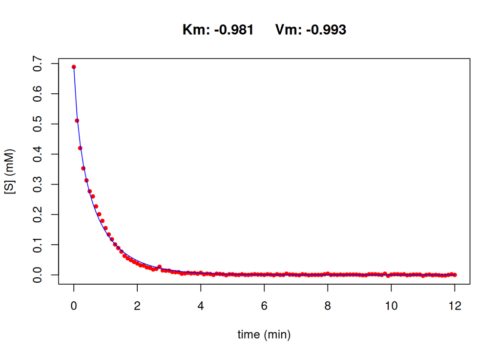

## 2. dir.MM(): non-linear least squares

If we calculate the initial velocity of the reaction at different substrate concentrations, we can generate an S vs V curve (velocity at different initial substrate concentrations). We can use this data to calculate Km and Vmax from substrate versus velocity curves using dir.MM().

### dir.MM(): toy data

Here is the output of dir.MM() using toy data provided with renz.

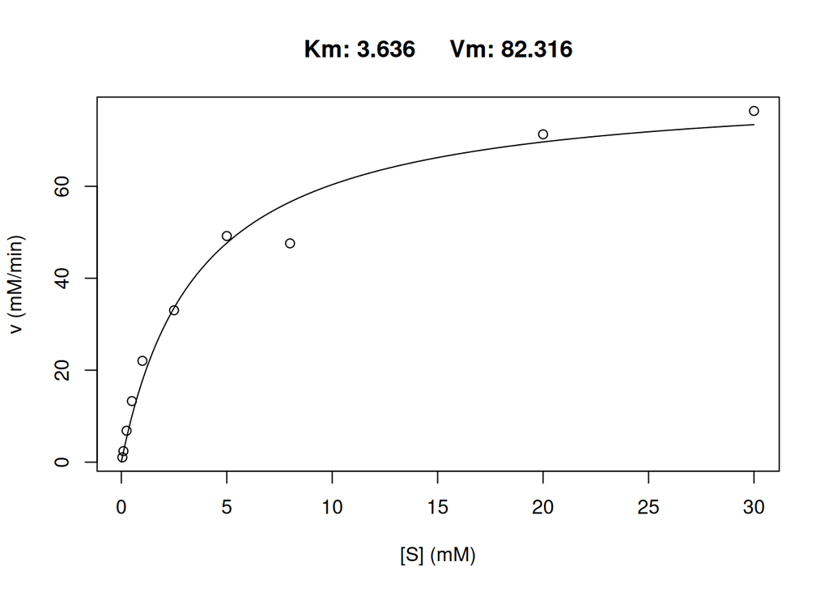

```
## $parameters
##     Km     Vm
##  3.636 82.316
##
## $data
## # A tibble: 10 × 3
##        S     v fitted_v
##    <dbl> <dbl>    <dbl>
##  1  0.05  1.04     1.12
##  2  0.1   2.40     2.20
##  3  0.25  6.84     5.30
##  4  0.5  13.3      9.95
##  5  1    22.0     17.8
##  6  2.5  33.0     33.5
##  7  5    49.2     47.7
##  8  8    47.6     56.6
##  9 20    71.3     69.7
## 10 30    76.4     73.4
```

```r
# laod toy data provided with renz
data(ONPG, package = "renz"); # load ONPG data

# Calc mean velocity of ONPG dataset
ONPG.data = ONPG %>%
  pivot_longer(cols = v1:v8, names_to = "Students", values_to = "Velocity");

ONPG.data = ONPG.data %>%
  select(ONPG, Velocity) %>%
  group_by(ONPG) %>%
  summarize(Velocity.mean = mean(Velocity));

dir.MM(ONPG.data, unit_v = "mM/min")
```

### dir.MM(): lab data

Here is the output of dir.MM() for our lab data.

```r
output = dir.MM(mydata.mm, unit_v = "mM/min")
```

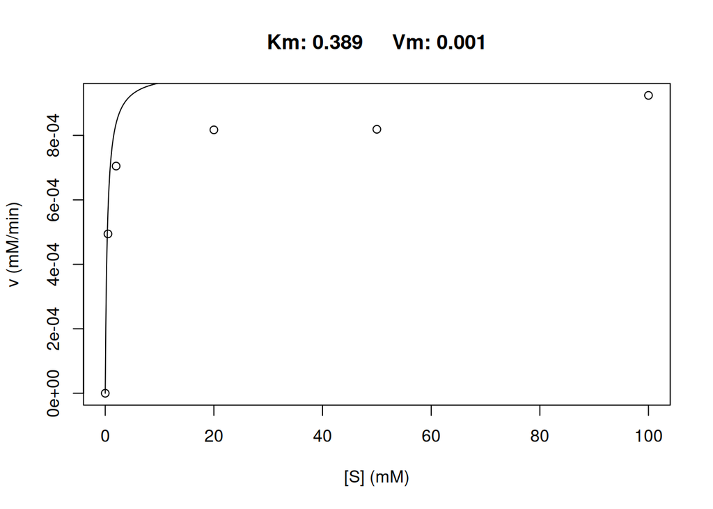

## 3. Lineweaver-Burke (LB): linear transformation.

Lineweaver-burke enables the calculation of Km and Vmax. Input data is the initial reaction velocity (V0) at various initial substrate concentrations (Vinitial vs Sinitial)

### LB linear regression: toy data

```r
data(ONPG, package = "renz"); # load ONPG data
ONPG[ , 4:7] <- 1000 * ONPG[ , 4:7]; # put all data on same scale

ONPG.data = ONPG %>%
  pivot_longer(cols = v1:v8, names_to = "Student", values_to = "Rate");

head(ONPG.data, 10)
```

```
## # A tibble: 10 × 3
##     ONPG Student  Rate
##    <dbl> <chr>   <dbl>
##  1  0.05 v1       2.26
##  2  0.05 v2       1.29
##  3  0.05 v3       4
##  4  0.05 v4       4
##  5  0.05 v5       4
##  6  0.05 v6       3
##  7  0.05 v7       1.77
##  8  0.05 v8       2.98
##  9  0.1  v1       5.48
## 10  0.1  v2       3.33
```

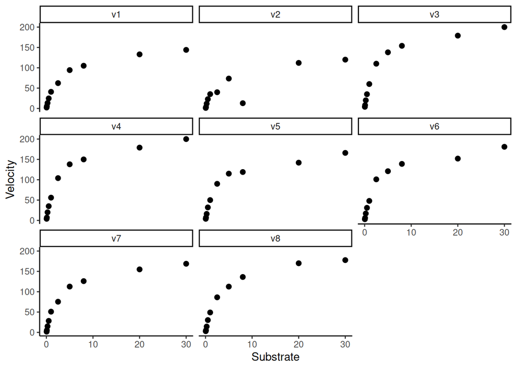

```r
# check data looks OK
p1=ggplot(ONPG.data, aes(x=ONPG, y=Rate))+
  geom_point(size = 2)+
  xlab("Substrate")+
  ylab("Velocity")+
  facet_wrap(~Student)+
  theme_classic();

p1
```

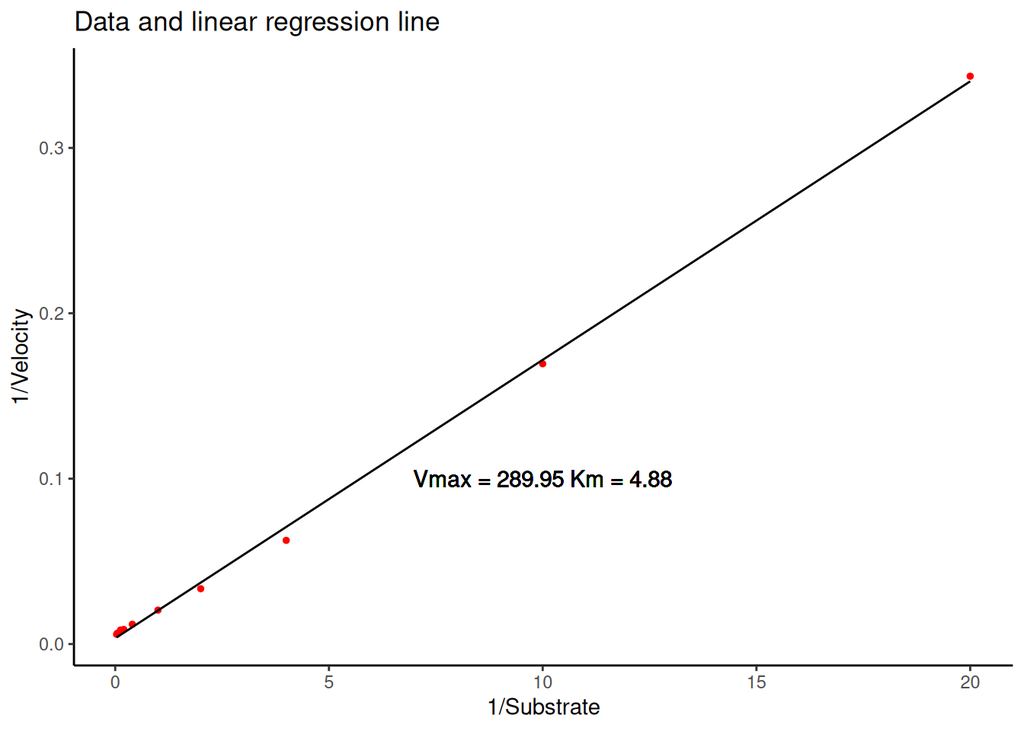

```r
# Method 1: linear regression of sample means
# get mean rate
ONPG.lineweaver = ONPG.data %>%
  group_by(ONPG) %>%
  reframe(Rate.mean = mean(Rate),
                             ONPG.inverse = 1/ONPG,
                             Rate.inverse = 1/Rate.mean) %>%
  distinct();

# fit linear model
lm.lin = lm(Rate.inverse ~ ONPG.inverse, ONPG.lineweaver);

# calc regression line
yintercept = lm.lin$coefficients[1];
myslope = lm.lin$coefficients[2];
Rate.inverse.calc = myslope * ONPG.lineweaver$ONPG.inverse + yintercept;
temp = data.frame(Rate.inverse.calc = Rate.inverse.calc)
ONPG.lineweaver = cbind(ONPG.lineweaver, temp);

# calc Vmax and Km
Vmax = 1/yintercept;
Km = Vmax * myslope;
text.out = paste("Vmax = ", round(Vmax, 2), " Km = ", round(Km, 2), sep = "");

# plot data (red points) and regression line (black line)
p3 = ggplot(ONPG.lineweaver, aes(x=ONPG.inverse, y=Rate.inverse)) +
 ggtitle("Data and linear regression line")+
 geom_point(size=1, color = "red") +
 xlab("1/Substrate") +
 ylab("1/Velocity") +
 geom_line(aes(x=ONPG.inverse, y=Rate.inverse.calc))+
 geom_text(x=10, y=0.1, label=text.out)+
 theme_classic();

p3
```

### Lineweaver-Burk weighted regression: toy data

```r
# Method 2: calc weighted linear regression for each sample, then take means
Km.all = numeric(0);
Vmax.all = numeric(0);
for (i in 2:9)
{
  wg = lb(ONPG[ , c(1,i)], weighting = TRUE);
  Km.all[i] = wg$fitted_parameters[1];
  Vmax.all[i] = wg$fitted_parameters[2];
}
```

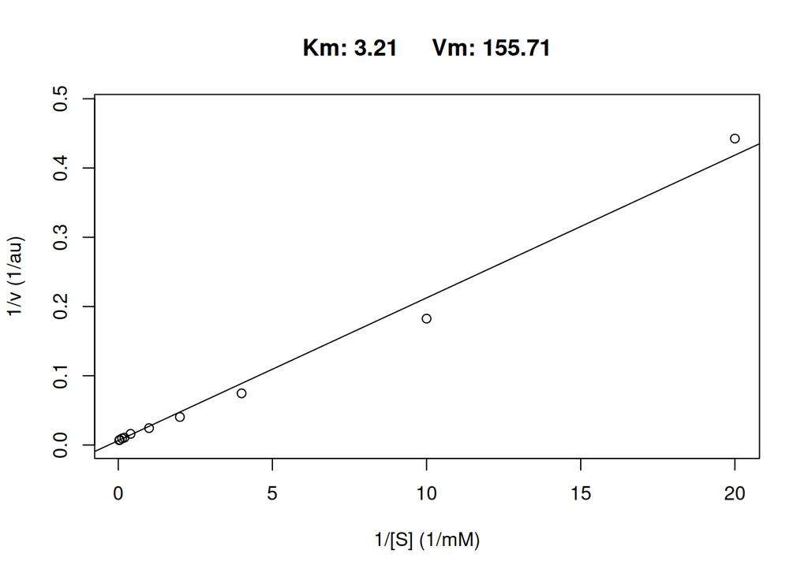

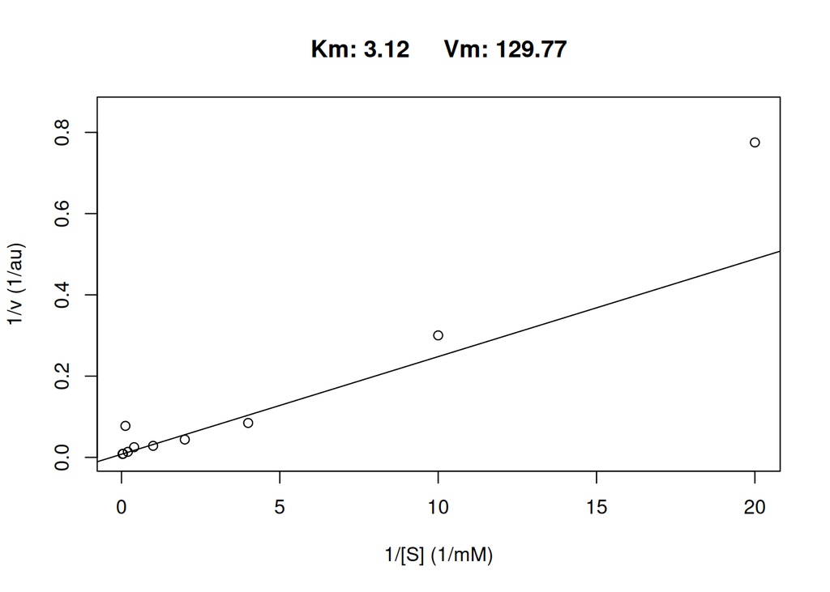

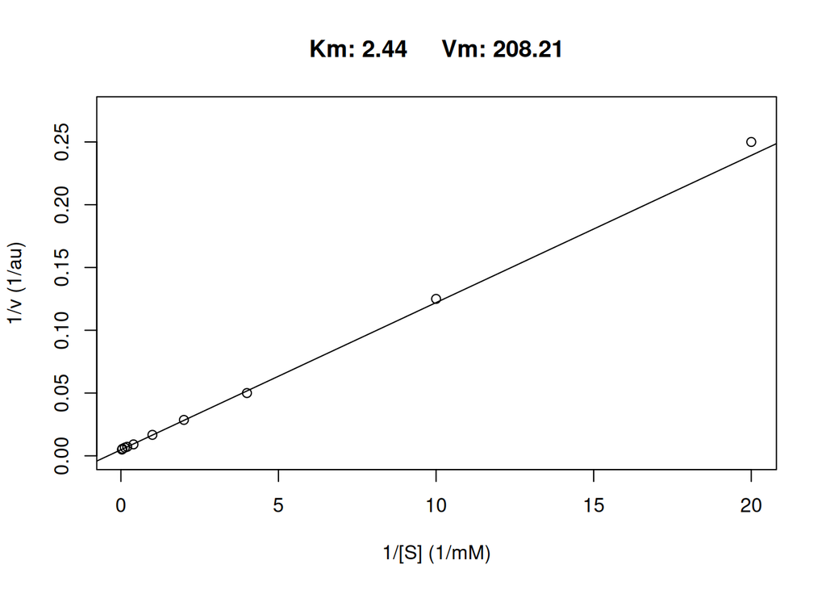

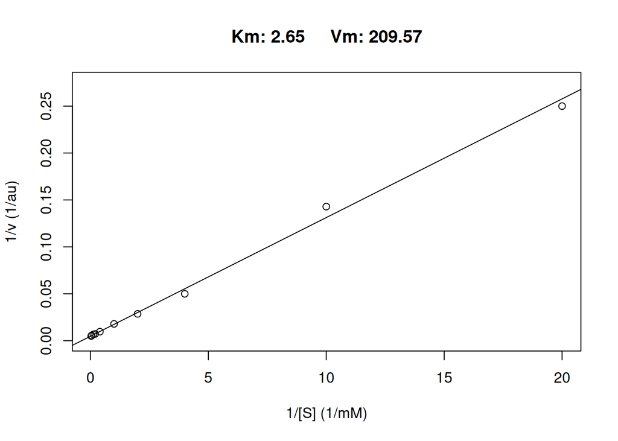

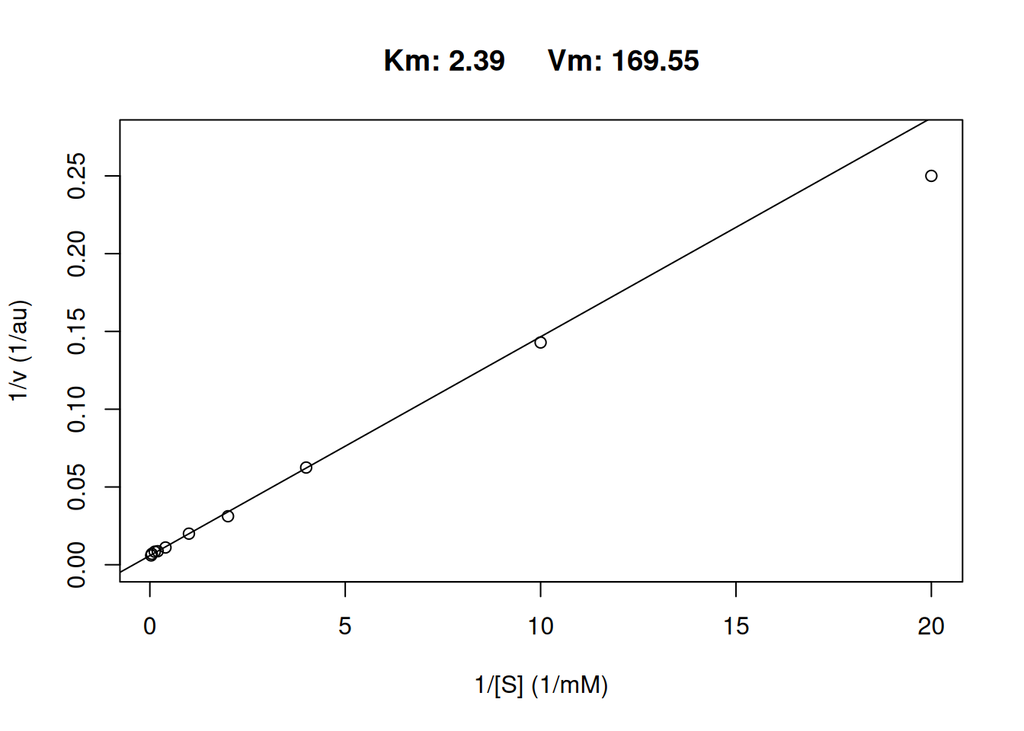

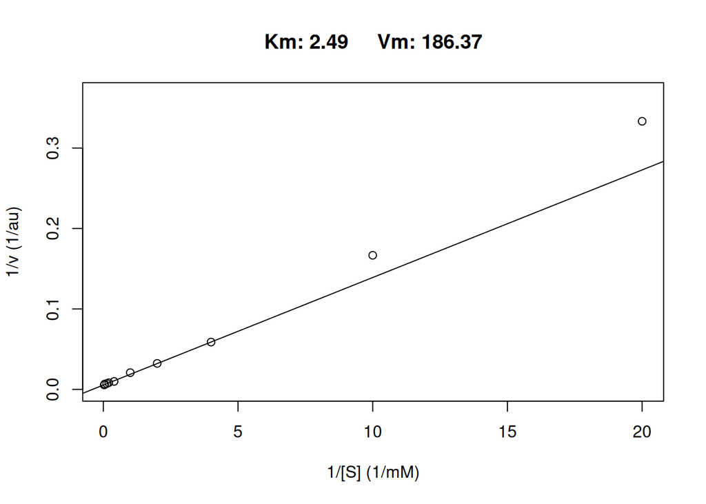

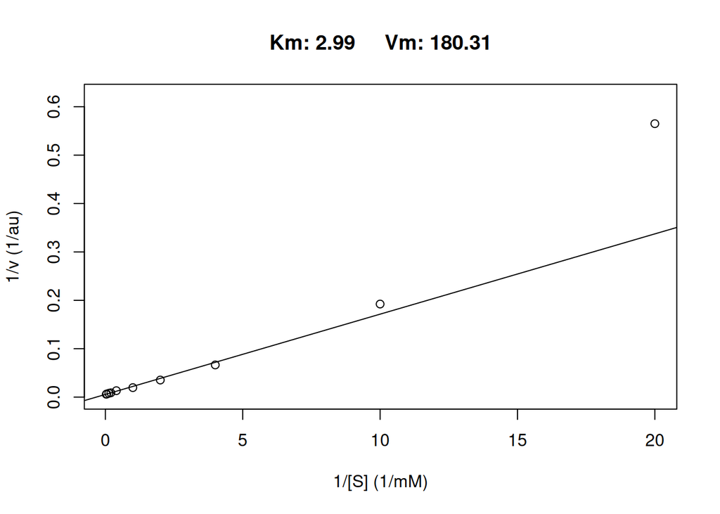

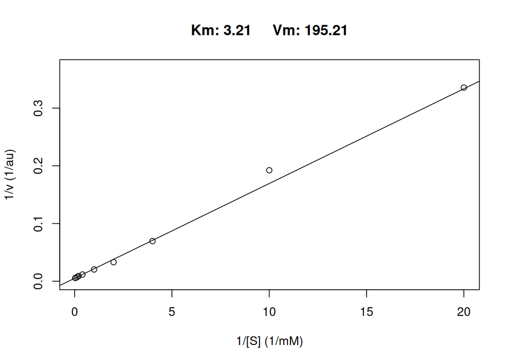

```r
Km.calc = mean(na.omit(Km.all));
Vmax.calc = mean(na.omit(Vmax.all));

Km.out = paste("The mean Km from weighted linear regression = ", Km.calc, sep = "");
Vmax.out = paste("The mean Vmax from weighted linear regression = ", Vmax.calc, sep = "");

Km.out
```

```
## [1] "The mean Km from weighted linear regression = 2.8125"
```

```r
Vmax.out
```

```
## [1] "The mean Vmax from weighted linear regression = 179.3375"
```

### Lineweaver-Burk: lab data

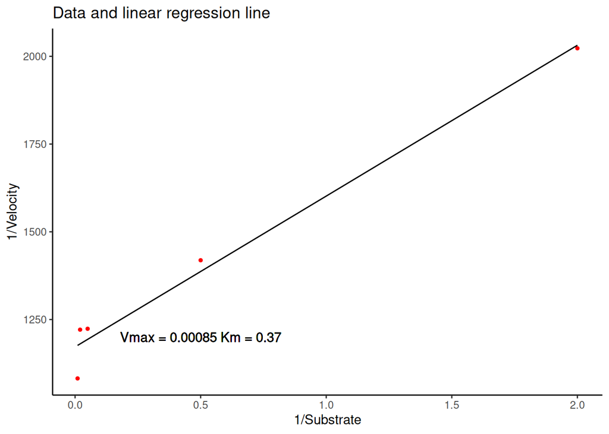

```r
# check data looks OK
p1=ggplot(mydata.lb, aes(x=Substrate_mM, y=Rate))+
  geom_point(size = 2)+
  xlab("Substrate")+
  ylab("Velocity")+
  theme_classic();

mydata = mydata.lb %>%
  mutate(Substrate.inverse = 1/Substrate_mM) %>%
  mutate(Rate.inverse = 1/Rate);

# remove row with inf (Substrate = 0)
mydata = mydata %>%
  filter_all(all_vars(!is.infinite(.)));

# fit linear model
lm.lin = lm(Rate.inverse ~ Substrate.inverse, mydata);

# calc regression line
yintercept = lm.lin$coefficients[1];
myslope = lm.lin$coefficients[2];
Rate.inverse.calc = myslope * mydata$Substrate.inverse + yintercept;
temp = data.frame(Rate.inverse.calc = Rate.inverse.calc)
mydata = cbind(mydata, temp);

# calc Vmax and Km
Vmax = 1/yintercept;
Km = Vmax * myslope;
text.out = paste("Vmax = ", round(Vmax, 5), " Km = ", round(Km, 2), sep = "");

# plot data (red points) and regression line (black line)
plotlb.data1 = ggplot(mydata, aes(x=Substrate.inverse, y=Rate.inverse)) +
 ggtitle("Data and linear regression line")+
 geom_point(size=1, color = "red") +
 xlab("1/Substrate") +
 ylab("1/Velocity") +
 geom_line(aes(x=Substrate.inverse, y=Rate.inverse.calc))+
 geom_text(x=0.5, y=1200, label=text.out)+
 theme_classic();

plotlb.data1
```

## se.Progress()

Calculate substrate consumption curve when given Km, Vmax, initial substrate

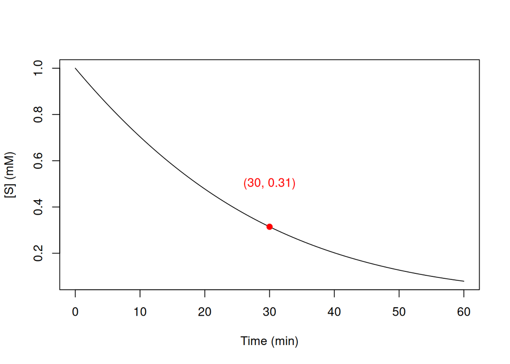

```r
# Enzyme parameters
So.test = 1;
time.test = 60;
Km.test = 2;
Vmax.test = 0.1;

data = sE.progress(So = So.test, time = time.test, Km = Km.test, Vm = Vmax.test, plot = FALSE)

# plot Substrate as a function of time
plot(data$t, data$St, ty = 'l', xlab = "Time (min)", ylab = "[S] (mM)")

# add red point when t = 30
points(data$t[which(data$t == 30)], data$St[which(data$t == 30)], pch = 19, col = "red")

# add text to point
text(30, 0.5, paste("(30, ", round(data$St[which(data$t == 30)], 2), ")", sep = ""), col = "red")
```